# DWEI5_Aula05_Flask-ModelsSQLAlchemyMigrate

[figure not shown]

Instituto Federal de São Paulo (IFSP)  
[Campus Bragança Paulista/SP](https://bra.ifsp.edu.br)  
**Análise e Desenvolvimento de Sistemas (ADS)**  
**5o. módulo**  
**Profa. Ana Paula Müller Giancoli**  
paulagiancoli@ifsp.edu.br

## AULA 05 - MODELS, SQLALCHEMY E MIGRATE

### Agenda

- O que é SQLAlchemy
  - O que é Migrate
- Adequando o Projeto para utilizar banco de dados
- Executando a migração
- Perguntas

### 1.1. O que é SQLAlchemy ?

- De acordo com [Andrade, Ana Paula (2019)](https://www.treinaweb.com.br/blog/o-que-e-o-sqlalchemy/), o SQLAlchemy é um framework de **M**apeamento **O**bjeto-**R**elacional SQL (ORM) de código aberto sobre a licença MIT.
- Consulte a [Documentação](https://flask-sqlalchemy.palletsprojects.com/en/2.x/).
- O **Mapeamento** é uma técnica de programação que auxilia na conversão de dados entre banco de dados relacionais e linguagens de programação que são orientadas a objetos.
- A utilização deste framework faz com que o programador reduza a programação de acesso ao banco de dados, desta forma, obtendo uma produtividade significativa no desenvolvimento de suas aplicações.
  - Cada **classe é interpretada como uma tabela**.
  - Cada **linha de uma determinada tabela, junto com seu relacionamento é tratada como instância do objeto** relacionado à tabela em questão.
  - Com ele, o desenvolvedor **não necessita se preocupar com a utilização de códigos SQL** no desenvolvimento de aplicações, já que todo acesso ao banco de dados é feito utilizando código Python.
  - Além disso, o SQLAlchemy possui todas as garantias de segurança necessárias para proteger as aplicações de ataques ao seus bancos de dados, garantindo, assim, a criação de aplicativos simples e seguros.

### 1.2. O que é Migrate ?

- Consulte a [Documentação](https://flask-migrate.readthedocs.io/en/latest/).
- O Flask-Migrate é uma extensão que lida com migrações de banco de dados SQLAlchemy para aplicativos Flask usando Alembic. As operações do banco de dados são disponibilizadas por meio da interface de linha de comando do Flask ou por meio da extensão Flask-Script.
- **OBS**: Sempre que ocorrer modificação nos modelos, este processo de migração deverá ser executado. Muitas vezes as alterações não são aplicadas, uma vez já criado o banco de dados. Neste caso, excluir os arquivos de **cache**, o **banco.db** criado dentro de projeto, e a pasta **migrations**. E executar novamente. Para um processo mais correto, efetuar uma pesquisa mais aprofundada para saber outras formas de correção.

### 2. Adequando o Projeto para utilizar banco de dados

### 2.1. Editando o arquivo config.py

- Localize o arquivo **config.py** na pasta **projeto**.
- Vamos utilizar o SQLITE como nosso banco de dados. A utilização do mySQL está fora do escopo proposto.
- Já inserimos inicialmente a configuração necessária para a criação de nosso banco de dados:

```
APP = None                                  <-------- Adicionar após esta linha

# Variável com o endereço do banco de dados. O método .join é utilizado para
# concatenar o nome completo contendo o endereço do banco de dados a ser utilizado pelo app.
# O banco de dados será chamado de app.db. Pode ser utilizado qualquer nome.
SQLALCHEMY_DATABASE_URI = 'sqlite:///' + os.path.join(ROOT_DIR, 'app.db')

# Configuração indicando que as modificações do banco de dados poderão ser exclusivamente pela aplicação.
# Se True, permite outras formas.
SQLALCHEMY_TRACK_MODIFICATIONS = False
```

### 2.2. Editando o arquivo app.py

- Localize o arquivo **app.py** na pasta **projeto**.

```
# ---> Código omitido para facilitar o entendimento
config = app_config[app_active]                                    <--- Adicione abaixo desta linha

# Importando a biblioteca do SQLAlchemy para manipular o banco de dados
from flask_sqlalchemy import SQLAlchemy

# --->  Código omitido para facilitar o entendimento
    app.config.from_pyfile('config.py')                            <--- Adicione abaixo desta linha

    # Adicionando configurações necessárias para utilizarmos o SQLAlchemy.
    # A constante SQLALCHEMY_DATABASE_URI foi definida no arquivo config.py, a qual indica o caminho do banco de dados.
    app.config['SQLALCHEMY_DATABASE_URI'] = config.SQLALCHEMY_DATABASE_URI

    # Configuração indicando que as modificações do banco de dados poderão ser exclusivamente pela aplicação.
    # Se True, permite outras formas.
    app.config['SQLALCHEMY_TRACK_MODIFICATIONS'] = False

    # A variável db receberá a atribuição de uma instância do SQLAlchemy passando a aplicação app criada.
    db = SQLAlchemy(config.APP)                <---  INSTÂNCIA db do SQLAlchemy a ser utilizada pelos models.

    # Inicializando o banco de dados para a aplicação.
    db.init_app(app)

# --->  Código omitido para facilitar o entendimento
```

### 2.3. Models

- **Models** são os *modelos das tabelas que serão criadas no banco de dados*. Para criarmos os models, utilizaremos o **SQLAlchemy** que nos auxiliará na criação dos modelos. E o **Migrate**, que nos auxiliará na migração e efetivação da criação do banco de dados.

### 2.3.1. class db.Model

- É chamada de **db.Model**, a classe básica para todos os modelos que utilizam **Flask-SQLAlchemy**.
- Ela é armazenada na instância SQLAlchemy que deve ser criada, neste caso, foi criada no arquivo **app.py** por meio da instrução:
  - **db = SQLAlchemy(config.APP)**.
- O **Flask-SQLAlchemy** permite algumas configurações como opcionais:
  - O nome da tabela é definido automaticamente, caso não seja informado.
  - Quando **omitido**, o **nome da tabela** é derivado do **nome da classe** convertido em minúsculas.
  - Para substituir o nome da tabela, defina o **atributo de classe __tablename__ = nometabela**.

### 2.3.2. Tipos de Colunas

| Tipo | Descrição significado |
| --- | --- |
| Integer | um inteiro |
| String(size) | uma string com um comprimento máximo (opcional em alguns bancos de dados, por exemplo, PostgreSQL) |
| Text | algum texto Unicode mais longo |
| DateTime | data e hora expressas como objeto Python datetime |
| Float | armazena valores de ponto flutuante |
| Boolean | armazena um valor booleano |
| PickleType | armazena um objeto Python em conserva |
| LargeBinary | armazena grandes dados binários arbitrários |

### 2.3.3. Relacionamentos entre modelos um para muitos

- De acordo com [Pallets Projects](https://flask-sqlalchemy.palletsprojects.com/en/2.x/models/), os relacionamentos de um para muitos são os mais comuns.

[output not shown]

### 2.3.4. Relacionamentos entre modelos muitos para muitos

- De acordo com [Pallets Projects](https://flask-sqlalchemy.palletsprojects.com/en/2.x/models/), os relacionamentos de muitos para muitos, será necessário definir uma tabela auxiliar que será usada para o relacionamento. Não utilizar a estrutura dos models.
- Para esta tabela auxiliar, é altamente recomendável não usar um modelo, mas uma tabela real:

```
tags = db.Table('tags',
    db.Column('tag_id', db.Integer, db.ForeignKey('tag.id'), primary_key=True),
    db.Column('page_id', db.Integer, db.ForeignKey('page.id'), primary_key=True)
)

class Page(db.Model):
    id = db.Column(db.Integer, primary_key=True)
    tags = db.relationship('Tag', secondary=tags, lazy='subquery', backref=db.backref('pages', lazy=True))

class Tag(db.Model):
    id = db.Column(db.Integer, primary_key=True)
```

### 2.4. Criando os modelos

### 2.4.1. Criando o arquivo Perfil.py

- Será responsável pela definição dos papeis dentro da aplicação, por exemplo: Admin, Professor, Aluno etc.

```
# -*- coding: utf-8 -*-
# Importando a biblioteca do SQLAlchemy para manipular o banco de dados
from flask_sqlalchemy import SQLAlchemy

# Importando o arquivo config com as configurações de ambiente
from config import app_active, app_config

# Criação da variável config para receber a atribuição do ambiente ativo.
config = app_config[app_active]

# Criação da variável db para receber a atribuição de uma instância do SQLAlchemy passando a aplicação app criada.
db = SQLAlchemy(config.APP)

# classe Perfil com 2 campos, o id e o nome do perfil.
class Perfil(db.Model):
    id=db.Column(db.Integer,primary_key=True)
    perfil=db.Column(db.String(40),unique=True,nullable=False)
```

### 2.4.2. Criando o arquivo Usuario.py

- Serão registrados todos os usuários da aplicação.

```
# -*- coding: utf-8 -*-
# Importando a biblioteca do SQLAlchemy para manipular o banco de dados
from flask_sqlalchemy import SQLAlchemy

# Importando o arquivo config com as configurações de ambiente
from config import app_active, app_config

# Importando a classe Perfil para ser utilizada na criação do relacionamento do usuario um-um.
# perfil=db.Column(db.Integer,db.ForeignKey(Perfil.id),nullable=False)
from models.Perfil import Perfil

# Criação da variável config para receber a atribuição do ambiente ativo.
config = app_config[app_active]

# Criação da variável db para receber a atribuição de uma instância do SQLAlchemy passando a aplicação app criada.
db = SQLAlchemy(config.APP)

# classe Usuario com 9 campos, sendo o id e o nome do usuario, email, senha, data de criação, última atualização, código de recuperação de senha que senha encriptado, se é perfil ativo e a chave estrangeira para a classe Perfil por meio do id do perfil.
class Usuario(db.Model):
    id=db.Column(db.Integer,primary_key=True)
    username=db.Column(db.String(40),unique=True,nullable=False)
    email=db.Column(db.String(120),unique=True,nullable=False)
    password=db.Column(db.String(80),nullable=False)
    date_created=db.Column(db.DateTime(6),default=db.func.current_timestamp(),nullable=False)
    last_update=db.Column(db.DateTime(6),onupdate=db.func.current_timestamp(),nullable=True)
    recovery_code=db.Column(db.String(100),nullable=True)
    active=db.Column(db.Boolean(),default=1,nullable=False)
    relacao=db.Column(db.Integer,db.ForeignKey(Perfil.id),nullable=False)
```

### 2.4.3. Criando o arquivo Area.py

- Será responsável pela definição das áreas dos componentes curriculares.

```
# -*- coding: utf-8 -*-
# Importando a biblioteca do SQLAlchemy para manipular o banco de dados
from flask_sqlalchemy import SQLAlchemy

# Importando o arquivo config com as configurações de ambiente
from config import app_active, app_config

# Criação da variável config para receber a atribuição do ambiente ativo.
config = app_config[app_active]

# Criação da variável db para receber a atribuição de uma instância do SQLAlchemy passando a aplicação app criada.
db = SQLAlchemy(config.APP)

# classe Area com 3 campos, sendo o id, o sigla da área e a descrição.
class Area(db.Model):
    id=db.Column(db.Integer,primary_key=True)
    area=db.Column(db.String(10),unique=True,nullable=False)
    descricao=db.Column(db.Text(),nullable=False)
```

### 2.4.4. Criando o arquivo Modulo.py

- Será responsável pela definição dos módulos de cada um dos componentes curriculares.

```
# -*- coding: utf-8 -*-
# Importando a biblioteca do SQLAlchemy para manipular o banco de dados
from flask_sqlalchemy import SQLAlchemy

# Importando o arquivo config com as configurações de ambiente
from config import app_active, app_config

# Criação da variável config para receber a atribuição do ambiente ativo.
config = app_config[app_active]

# Criação da variável db para receber a atribuição de uma instância do SQLAlchemy passando a aplicação app criada.
db = SQLAlchemy(config.APP)

# classe Modulo com 3 campos, sendo o id, o sigla do modulo e a descrição.
class Modulo(db.Model):
    id=db.Column(db.Integer,primary_key=True)
    modulo=db.Column(db.String(10),unique=True,nullable=False)
    descricao=db.Column(db.Text(),nullable=False)
```

### 2.4.5. Criando o arquivo Componente.py

- Responsável por armazenar os componentes curriculares.

[output not shown]

### 2.4.7. Criando o arquivo migrate.py

- Responsável por migrar os modelos do banco de dados. Será executado sempre que houver alguma modificação estrutural no BD.
- Para criá-lo, copie e cole as classes aqui, somente as classes e não as importações delas.

```
# Usado somente para criar o banco sqlite e as migrações dos modelos e sempre que alterar algum modelo, copiar novamente a classe e executar.

from flask import Flask
from flask_sqlalchemy import SQLAlchemy
from flask_script import Manager
from flask_migrate import Migrate, MigrateCommand
from config import app_active, app_config


config = app_config[app_active]
app = Flask(__name__)
app.config['SQLALCHEMY_DATABASE_URI'] = config.SQLALCHEMY_DATABASE_URI
app.config['SQLALCHEMY_TRACK_MODIFICATIONS'] = config.SQLALCHEMY_TRACK_MODIFICATIONS
db = SQLAlchemy(app)
migrate = Migrate(app, db)
manager = Manager(app)
manager.add_command('db', MigrateCommand)

# ADICIONAR AQUI OS MODELS
# IMPORTANTE, LEMBRAR DAS DEPENDÊNCIAS NA CRIAÇÃO


class Perfil(db.Model):
    id=db.Column(db.Integer,primary_key=True)
    perfil=db.Column(db.String(40),unique=True,nullable=False)

class Usuario(db.Model):
    id=db.Column(db.Integer,primary_key=True)
    username=db.Column(db.String(40),unique=True,nullable=False)
    email=db.Column(db.String(120),unique=True,nullable=False)
    password=db.Column(db.String(80),nullable=False)
    date_created=db.Column(db.DateTime(6),default=db.func.current_timestamp(),nullable=False)
    last_update=db.Column(db.DateTime(6),onupdate=db.func.current_timestamp(),nullable=True)
    recovery_code=db.Column(db.String(100),nullable=True)
    active=db.Column(db.Boolean(),default=1,nullable=False)
    relacao=db.Column(db.Integer,db.ForeignKey(Perfil.id),nullable=False)

class Area(db.Model):
    id=db.Column(db.Integer,primary_key=True)
    area=db.Column(db.String(10),unique=True,nullable=False)
    descricao=db.Column(db.Text(),nullable=False)


class Modulo(db.Model):
    id=db.Column(db.Integer,primary_key=True)
    modulo=db.Column(db.String(10),unique=True,nullable=False)
    descricao=db.Column(db.Text(),nullable=False)


class Componente(db.Model):
    id=db.Column(db.Integer,primary_key=True)
    sigla=db.Column(db.String(10),unique=True,nullable=False)
    descricao=db.Column(db.Text(),nullable=False)
    qtdeaulas=db.Column(db.Integer)
    date_created=db.Column(db.DateTime(6),default=db.func.current_timestamp(),nullable=False)
    last_update=db.Column(db.DateTime(6),onupdate=db.func.current_timestamp(),nullable=False)
    status=db.Column(db.Boolean(),default=1,nullable=True)
    user_created=db.Column(db.Integer,db.ForeignKey(Usuario.id),nullable=False)
    areaid=db.Column(db.Integer,db.ForeignKey(Area.id),nullable=False)
    moduloid=db.Column(db.Integer,db.ForeignKey(Modulo.id),nullable=False)


if __name__ == '__main__':
    manager.run()
```

### 3. Executando a migração

- No terminal, ative o ambiente virtual. Caso não tenha instalado, siga os processos definidos nas aulas anteriores:
  - (1) De dentro da pasta **projeto**, execute: **python -m venv venv**.
  - (2) Ative o ambiente virtual, digite: **source venv/bin/activate**, para o SO Windows, consulte as aulas anteriores.
  - (3) Instale as bibliotecas necessárias para o Flask, utilizando o arquivo instalar.sh ou instalar.bat (conforme seu SO).
  - (4) Defina a **variável de ambiente FLASK_ENV=development**, indicando que estamos executando no ambiente de desenvolvimento.
  - **Observação**: Se as etapas 1 e 3 já foram feitas, basta executar as etapas 2 e 4 para dar continuidade.
- Em seguida, para efetuar a migração:
  - Inicialize a configuração do migrate, digitando de dentro da pasta **projeto** e com o ambiente virtual ativo:

#### python migrate.py db init

- Será exibido algo parecido com isso:

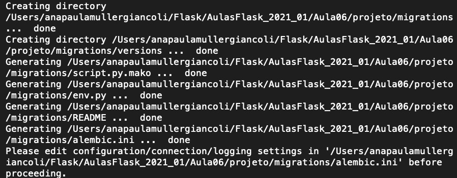

#### python migrate.py db migrate

- Será exibido algo parecido com isso:

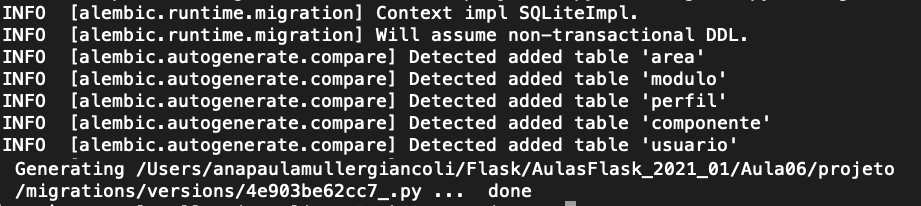

- Será exibido algo parecido com isso:

[figure not shown]

#### Verifique se o banco foi criado e suas tabelas, abra o **software db browser**. O nome do banco criado será o que foi definido no arquivo config.py

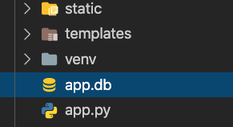

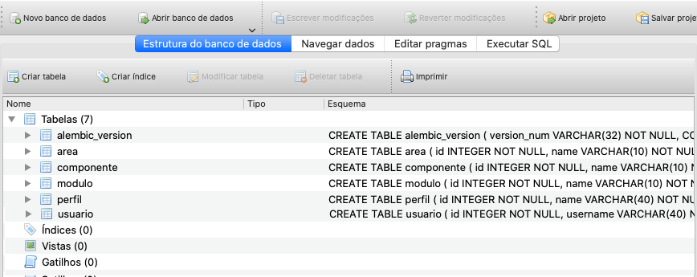

### ATENÇÃO

- **Lembre-se de encerrar o servidor ao final de cada aula**.
- **Lembre-se também, de desativar o ambiente virtual**.

### Referências

- Esta aula foi elaborada a partir do conteúdo disponibilizado em cada um dos links indicados no próprio texto.

### Perguntas

- Esclareça suas eventuais dúvidas durante as aulas.
- Ou pelo *E-mail*: paulagiancoli@ifsp.edu.br.
- Ou acesse [Github Ana Giancoli](https://anagiancoli.github.io) e solicite atendimento para o componente curricular.

*ADS - HTML5, CSS3, JS, FLASK - 5o. módulo*.  
Modelo e formato elaborado por profa. Ana Paula Müller Giancoli - BSD 2-Clause License. - Fevereiro.2021.